# Thesis Maury Kros

## Preface

This notebook serves as supplementary material to the master thesis. Over the course of the thesis we have worked in many notebooks and experimented with many more. Here, the goal is to create a complete but brief compilation of the code that is used to recreate the figures and tables that are present in the thesis. We comment on to which part of the thesis the code relates to and add comments in the codeblocks themselves to improve readability. In this notebook we cover:

- The plot from section 2
- Recreate the results from section 3. This consists of:
  - The function that is used to run one trial with a choice of design parameters
  - Results in table 1
  - Results in table 2

## Section 2

In this section we provide the code for the plot at the end of section 2 in the thesis. Note that there is sampling variability in the plot since patients are drawn from a population, so we might end up with a slightly different plot. Since this plot only serves to make the theory in section 2 visual, we ended up selecting a plot that looked appealing.

```r
#We pick a cohortsize and generate a population of 2*cohortsize with response rate = 0.55
cohortsize <- 16
patients <- rbinom(2*cohortsize, 1, 0.55)

#We compute the parameters of the prior and posterior distributions
a1 <- sum(patients[1:cohortsize])+1
b1 <- cohortsize-sum(patients[1:cohortsize])+1
a2 <- sum(patients[1:(2*cohortsize)])+1
b2 <- (2*cohortsize)-sum(patients[1:(2*cohortsize)])+1

par(mfrow = c(1,2))

#x-axis
x <- seq(0, 1, length.out=1000)

#After first group
prior <- dbeta(x, 1, 1)
posterior <- dbeta(x, a1, b1)
plot(x, prior, type = "l", main = bquote("Cohort 1"), xlab = bquote(theta), ylab = bquote("P" (theta) ), ylim=c(0,7), col = "blue", lwd = 1.5)
lines(x, posterior, col = "red", lwd = 1.5)
```

```r
fillcol <- rgb(0.976, 0.184, 0.223, 0.5)
polygon(c(x[x>=0.4], max(x), 0.4), c(posterior[x>=0.4], 0, 0), angle = 45, col= fillcol, border = fillcol)
legend("topleft",
       legend = c("Prior Beta(1,1)", paste0('Posterior Beta(', a1,',' ,b1, ')')),
       col = c("blue", "red"),
       pch = c(15,15))
```

```r
#After second group
prior <- dbeta(x, a1, b1)
posterior <- dbeta(x, a2, b2)
plot(x, prior, type = "l", main = bquote("Cohort 2"), xlab = bquote(theta), ylab = bquote("P" (theta) ), ylim=c(0,7), col = "blue", lwd = 1.5)
lines(x, posterior, col = "red", lwd = 1.5)
```

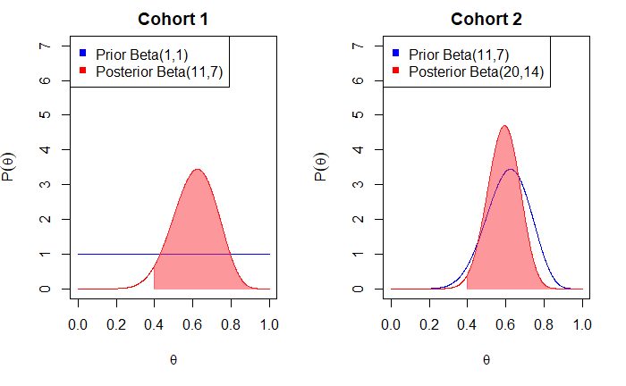

```r
polygon(c(x[x>=0.4], max(x), 0.4), c(posterior[x>=0.4], 0, 0), angle = 45, col= fillcol, border = fillcol)
legend("topleft",
       legend = c(paste0('Prior Beta(', a1,',' ,b1, ')'), paste0('Posterior Beta(', a2,',' ,b2, ')')),
       col = c("blue", "red"),
       pch = c(15,15))
```

### Section 3

### Simulation of one trial

First, a function that simulates one trial with a choice of design parameters is written, say $OneTrial()$. This function will be used over and over again. This function takes 5 arguments:

- An array that represents the cohorts of patients.
- The response rate for simulatingthe type I error rate $\theta_I$
- The response rate for simulatingthe type I error rate $\theta_{II}$
- The lower limit $\phi$ for the response rate which is deemed acceptable
- The posterior mass above $\phi$ required to conclude superiority, denoted $p_{cut}$

Note that by passing an array of cohorts, you implicitly pass various design parameters: the number of cohorts $k$, the cohortsize $n_k$, the minimum number of patients $n_{min} = n_k$ and maximum number of patients $n_{max} = k \cdot n_k$. The function is written in such a way that the output is an array of all design parameters and operating characteristics. This is illustrated in the example below.

```r
OneTrial <- function(cohorts = c(5,5,5,5),
                     responserate_i = 0.4,
                     responserate_ii = 0.6,
                     rr_decision = 0.4,
                     pcutoff = 0.95){

  #Prior selection
  alpha_prior <- 1
  beta_prior <- 1

  #Number of simulations, note that the total number of simulation runs is 2*nsim
  nsim <- 1000

  #Variables to keep track of TP's, FP's etc...
  tp <- 0
  fp <- 0
  fn <- 0
  tn <- 0
  biassum <- 0

  #We also want to know on average how much patients we use
  psum <- 0


  #Type I error rate
  for(i in 1:nsim){

    #Sample from population
    responserate <- responserate_i
    patients <- rbinom(sum(cohorts), 1, responserate)

    #Initialization of true and concluded hypotheses
    true_hyp <- 0
    concluded_hyp <- 0

    #Store parameters of the posterior distribution for bias computation
    alpha_posterior_bc <- 0
    beta_posterior_bc <- 0

    #Run trial
    for (j in 1:length(cohorts)) {

      #Find number of patients and successes after j nrounds
      num_patients <- sum(cohorts[1:j])
      successes <- sum(patients[1:num_patients])

      #Compute beliefs
      alpha_posterior <- successes + alpha_prior
      beta_posterior <- num_patients - successes  + beta_prior
      c_theta = 1-pbeta(rr_decision, alpha_posterior, beta_posterior)

      #Update outerloop variables for bias computation
      alpha_posterior_bc <- alpha_posterior
      beta_posterior_bc <- beta_posterior

      if (c_theta > pcutoff){
        concluded_hyp <- 1
        break
      }


    }

    #Update outerloop variables
    if(concluded_hyp == 0) {
        # h0 is true, we conclude h0
        tn <- tn + 1
      }else{
        #h0 is true, we conclude h1
        fp <- fp + 1
      }

    #Update biassum
    mean_post <- alpha_posterior_bc / (alpha_posterior_bc +     beta_posterior_bc)
    biassum <- biassum + (responserate_i - mean_post)

    #Update psum
    psum <- psum + num_patients

  }

  #Type II error rate / Power
  for(i in 1:nsim){

    #Sample from population
    #Response rate ligt nu tussen de rr_decision value en 1 in
    responserate <- responserate_ii
    patients <- rbinom(sum(cohorts), 1, responserate)

    #Initialization of true and concluded hypotheses
    true_hyp <- 1
    concluded_hyp <- 0

    alpha_posterior_bc <- 0
    beta_posterior_bc <- 0

    #Run trial
    for (j in 1:length(cohorts)) {

      #Find number of patients and successes after j nrounds
      num_patients <- sum(cohorts[1:j])
      successes <- sum(patients[1:num_patients])

      #Compute beliefs
      alpha_posterior <- successes + alpha_prior
      beta_posterior <- num_patients - successes  + beta_prior
      c_theta = 1-pbeta(rr_decision, alpha_posterior, beta_posterior)

      alpha_posterior_bc <- alpha_posterior
      beta_posterior_bc <- beta_posterior

      if (c_theta > pcutoff){
        concluded_hyp <- 1
        break
      }
    }

    #Update outerloop variables
    if(concluded_hyp == 0){
        # h0 is false, we conclude h0
        fn <- fn + 1
      }else{
        # h0 is false, we conclude h1
        tp <- tp + 1
      }

    #Update biassum
    mean_post <- alpha_posterior_bc / (alpha_posterior_bc +     beta_posterior_bc)
    biassum + (responserate_ii - mean_post)

    #Update psum
    psum <- psum + num_patients

  }



  #Return the summary of the simulated trial
  values <- c(cohorts[1], sum(cohorts), rr_decision, pcutoff, fp/(fp+tn), fn/(fn+tp), 1-fn/(fn+tp), biassum / (2*nsim), psum / (2*nsim), responserate_i, responserate_ii)
  output <- matrix(values,
                   nrow = 1,
                   ncol = 11)
  colnames(output) <- c('nmin', 'nmax', 'rr_decision', 'pcutoff', 'Type I Error rate', 'Type II Error rate', 'Power', 'Bias', 'avg(n)', 'Response rate I', 'Response rate II')

  return(output)

}
```

#### Example trial

We want to evaluate the operating characteristics of a trial with $k = 3$ cohorts with cohortsize $n_k$ 5. We pick $\theta_I = 0.4$ and $\theta_I = 0.6$. In particular, we are interested if we can set up a trial in such a way that we can acquire a type I error rate $\alpha = 0.05$ and a power of $\beta = 0.80$. We determine that a treatment is effective if the response rate exceeds 0.40 and we want that the posterior mass above 0.40 exceeds 0.95, so here $\phi = 0.40$ and $p_{cut} = 0.95$. We find that we do not acquire the required operating characteristics.

```r
OneTrial(cohorts = c(5,5,5),
                     responserate_i = 0.4,
                     responserate_ii = 0.6,
                     rr_decision = 0.4,
                     pcutoff = 0.95)
```

```
     nmin nmax rr_decision pcutoff Type I Error rate Type II Error rate Power        Bias  avg(n) Response rate I
[1,]    5   15         0.4    0.95             0.134              0.469 0.531 -0.01714881 12.4425             0.4
     Response rate II
[1,]              0.6
```

#### Results Table 1

In the example above, we pick design parameters and determine the values for the operating characteristics we intend to acquire. In a nutshell, this is also what happens in the results section of the thesis. In the codeblock below we recreate the results that are displayed in table 1 in the thesis. The random seed is fixed so that the results are identical. Since we only have to create two tables, we opted to manually put the values we got into latex and to the formatting there.

```r
set.seed(0)

#Designs D7-D12
#Same size in cohorts, all else unchanged (ptrue = 0.50)
OneTrial(cohorts = c(156), responserate_i = 0.4, responserate_ii = 0.5, rr_decision = 0.4)
```

```
     nmin nmax rr_decision pcutoff Type I Error rate Type II Error rate Power          Bias avg(n) Response rate I
[1,]  156  156         0.4    0.95             0.048              0.181 0.819 -0.0009556962    156             0.4
     Response rate II
[1,]              0.5
```

```r
OneTrial(cohorts = c(78,78), responserate_i = 0.4, responserate_ii = 0.5, rr_decision = 0.4)
```

```
     nmin nmax rr_decision pcutoff Type I Error rate Type II Error rate Power          Bias  avg(n) Response rate I
[1,]   78  156         0.4    0.95             0.072               0.17  0.83 -0.0007299842 132.444             0.4
     Response rate II
[1,]              0.5
```

```r
OneTrial(cohorts = c(52,52,52), responserate_i = 0.4, responserate_ii = 0.5, rr_decision = 0.4)
```

```
     nmin nmax rr_decision pcutoff Type I Error rate Type II Error rate Power         Bias  avg(n) Response rate I
[1,]   52  156         0.4    0.95             0.111               0.12  0.88 -0.004155338 120.354             0.4
     Response rate II
[1,]              0.5
```

```r
OneTrial(cohorts = c(39,39,39,39), responserate_i = 0.4, responserate_ii = 0.5, rr_decision = 0.4)
```

```
     nmin nmax rr_decision pcutoff Type I Error rate Type II Error rate Power         Bias  avg(n) Response rate I
[1,]   39  156         0.4    0.95             0.128              0.131 0.869 -0.005313897 115.401             0.4
     Response rate II
[1,]              0.5
```

```r
OneTrial(cohorts = c(31,31,31,31,31), responserate_i = 0.4, responserate_ii = 0.5, rr_decision = 0.4)
```

```
     nmin nmax rr_decision pcutoff Type I Error rate Type II Error rate Power         Bias  avg(n) Response rate I
[1,]   31  155         0.4    0.95             0.135              0.135 0.865 -0.005030482 112.344             0.4
     Response rate II
[1,]              0.5
```

```r
OneTrial(cohorts = rep(1, 156), responserate_i = 0.4, responserate_ii = 0.5, rr_decision = 0.4)
```

```
     nmin nmax rr_decision pcutoff Type I Error rate Type II Error rate Power       Bias avg(n) Response rate I
[1,]    1  156         0.4    0.95             0.343               0.08  0.92 -0.0373602 79.792             0.4
     Response rate II
[1,]              0.5
```

```r
print('--- break ---', quote = F)
```

```
[1] --- break ---
```

```r
#Designs: D1-D6
#Same size in cohorts, but we start from a fixed sample calc with small effect size (ptrue = 0.45)
OneTrial(cohorts = c(605), responserate_i = 0.4, responserate_ii = 0.45, rr_decision = 0.4)
```

```
     nmin nmax rr_decision pcutoff Type I Error rate Type II Error rate Power          Bias avg(n) Response rate I
[1,]  605  605         0.4    0.95             0.057              0.185 0.815 -0.0003319605    605             0.4
     Response rate II
[1,]             0.45
```

```r
OneTrial(cohorts = c(303,303), responserate_i = 0.4, responserate_ii = 0.45, rr_decision = 0.4)
```

```
     nmin nmax rr_decision pcutoff Type I Error rate Type II Error rate Power         Bias  avg(n) Response rate I
[1,]  303  606         0.4    0.95             0.083              0.168 0.832 -0.001294731 516.312             0.4
     Response rate II
[1,]             0.45
```

```r
OneTrial(cohorts = c(202,202,202), responserate_i = 0.4, responserate_ii = 0.45, rr_decision = 0.4)
```

```
     nmin nmax rr_decision pcutoff Type I Error rate Type II Error rate Power          Bias avg(n) Response rate I
[1,]  202  606         0.4    0.95              0.09              0.176 0.824 -0.0007888632 482.78             0.4
     Response rate II
[1,]             0.45
```

```r
OneTrial(cohorts = c(152,152,152,152), responserate_i = 0.4, responserate_ii = 0.45, rr_decision = 0.4)
```

```
     nmin nmax rr_decision pcutoff Type I Error rate Type II Error rate Power         Bias  avg(n) Response rate I
[1,]  152  608         0.4    0.95             0.105              0.146 0.854 -0.001778535 456.304             0.4
     Response rate II
[1,]             0.45
```

```r
OneTrial(cohorts = c(122,122,122,122,122), responserate_i = 0.4, responserate_ii = 0.45, rr_decision = 0.4)
```

```
     nmin nmax rr_decision pcutoff Type I Error rate Type II Error rate Power         Bias avg(n) Response rate I
[1,]  122  610         0.4    0.95             0.146              0.109 0.891 -0.003480569 438.59             0.4
     Response rate II
[1,]             0.45
```

```r
OneTrial(cohorts = rep(1, 603), responserate_i = 0.4, responserate_ii = 0.45, rr_decision = 0.4)
```

```
     nmin nmax rr_decision pcutoff Type I Error rate Type II Error rate Power        Bias   avg(n) Response rate I
[1,]    1  603         0.4    0.95             0.419              0.056 0.944 -0.03841931 270.6465             0.4
     Response rate II
[1,]             0.45
```

```r
print('--- break ---', quote = F)
```

```
[1] --- break ---
```

```r
#Designs: D13-D15
#Same size in cohorts, but we start from a fixed sample calc with big effect size (ptrue = 0.55)
OneTrial(cohorts = c(69), responserate_i = 0.4, responserate_ii = 0.55, rr_decision = 0.4)
```

```
     nmin nmax rr_decision pcutoff Type I Error rate Type II Error rate Power         Bias avg(n) Response rate I
[1,]   69   69         0.4    0.95             0.045              0.206 0.794 -0.000443662     69             0.4
     Response rate II
[1,]             0.55
```

```r
OneTrial(cohorts = c(35,35), responserate_i = 0.4, responserate_ii = 0.55, rr_decision = 0.4)
```

```
     nmin nmax rr_decision pcutoff Type I Error rate Type II Error rate Power        Bias  avg(n) Response rate I
[1,]   35   70         0.4    0.95             0.099              0.124 0.876 -0.00430518 57.8375             0.4
     Response rate II
[1,]             0.55
```

```r
OneTrial(cohorts = c(23,23,23), responserate_i = 0.4, responserate_ii = 0.55, rr_decision = 0.4)
```

```
     nmin nmax rr_decision pcutoff Type I Error rate Type II Error rate Power        Bias  avg(n) Response rate I
[1,]   23   69         0.4    0.95             0.093              0.156 0.844 -0.00491831 55.0045             0.4
     Response rate II
[1,]             0.55
```

#### Results Table 2

In the codeblock below we recreate the results for table 2.

```r
set.seed(0)

#D16
#More stringent cutoff value
OneTrial(cohorts = c(78,78), responserate_i = 0.4, responserate_ii = 0.5, rr_decision = 0.4, pcutoff = 0.9642)
```

```
     nmin nmax rr_decision pcutoff Type I Error rate Type II Error rate Power         Bias  avg(n) Response rate I
[1,]   78  156         0.4  0.9642             0.045              0.204 0.796 -0.001697468 136.656             0.4
     Response rate II
[1,]              0.5
```

```r
#D17
#Increase n in combination with cutoff value
OneTrial(cohorts = c(52,52,52,52), responserate_i = 0.4, responserate_ii = 0.5, rr_decision = 0.4, pcutoff = 0.985)
```

```
     nmin nmax rr_decision pcutoff Type I Error rate Type II Error rate Power         Bias  avg(n) Response rate I
[1,]   52  208         0.4   0.985              0.04              0.179 0.821 -0.001463562 167.388             0.4
     Response rate II
[1,]              0.5
```

```r
#D18
#Only increasing n does not bring us much
OneTrial(cohorts = c(52,52,52,52), responserate_i = 0.4, responserate_ii = 0.5, rr_decision = 0.4, pcutoff = 0.95)
```

```
     nmin nmax rr_decision pcutoff Type I Error rate Type II Error rate Power         Bias avg(n) Response rate I
[1,]   52  208         0.4    0.95             0.129              0.063 0.937 -0.004625442 147.42             0.4
     Response rate II
[1,]              0.5
```

```r
#D19
OneTrial(cohorts = c(152,152,152,152), responserate_i = 0.4, responserate_ii = 0.475, rr_decision = 0.4, pcutoff = 0.98)
```

```
     nmin nmax rr_decision pcutoff Type I Error rate Type II Error rate Power          Bias  avg(n) Response rate I
[1,]  152  608         0.4    0.98             0.041              0.036 0.964 -0.0003621876 445.436             0.4
     Response rate II
[1,]            0.475
```